# Exploring Neural Activity in Steinmetz Mouse Experiment

Seok Hyun Kim

2023-06-10

STA 141 Project

## Abstract:

Our project is based on the Steinmetz mouse experiment conducted in 2019. The study aimed to examine the behavior of 10 male and female mice by analyzing the activities of approximately 30,000 neurons across 42 brain areas. The researchers discovered that prior to starting a task, the brain’s overall activity could predict how engaged the mice would be during each trial and throughout the entire task. When the mice were engaged, their lower-level brain activity (subcortical) became stronger, while their higher-level brain activity (neocortical) became weaker.

In our project, we focused on a subset of data from the Steinmetz experiment, specifically data from four out of the ten mice. We examined the spiking activity of neurons in various crucial brain areas between trials and within sessions, identifying trends in response time and engagement variability. Through this analysis, we observed that the mice named Cori and Lederberg exhibited similar patterns of neuron activity, while Hench and Forssmann showed similar trends in neuron activity. Furthermore, we discovered that neuron spiking activity in the root area and the CA area played a significant role in understanding the mice’s neuron activity.

## Section 1 Introduction:

#Introduce the objective and briefly review the background of this data set

If the left stimuli had a stronger intensity, the mouse’s successful task was to turn the wheel to the left. Conversely, if the right stimuli were stronger, the successful task was to turn the wheel to the right. When both left and right stimuli had equal intensities, the correct wheel turning direction was randomized. In each trial, the mouse received a reward for successfully completing the task and a penalty for failure. The correct/incorrect of the mouse for each trial is recorded as the variable “feedback”, -1 for incorrect and 1 for correct.

Throughout the experiment, scientists monitored the neural activities of each mouse, specifically focusing on the spikes of stimulation occurring in their neurons. The scientists recorded the spiking trains of each responsive neuron 0.4 seconds after the onset of stimulation. Additionally, they noted the location of each neuron in the brain.

The purpose of this project is to predict the feedback type of 100 random trials each from session 1 and session 18 using the mice’s neuron activity and data trends.

First we load the packages that we need to run the code in our project, as well the data from our exeriment.

```r
options(repos = list(CRAN="http://cran.rstudio.com/"))
install.packages("devtools")
```

```r
knitr::opts_chunk$set(eval = TRUE, echo = TRUE, fig.align='center')
install.packages("tidyverse")
library(tidyverse)
install.packages("knitr")
library(knitr)
install.packages("dplyr")
library(dplyr)
install.packages("kableExtra")
install.packages("rvest")
library(kableExtra)
library(rvest)
session=list()
for(i in 1:18){
  session[[i]]=readRDS(paste('~/Downloads/sessions/session',i,'.rds',sep=''))
}
```

## Section 2 Exploratory analysis:

#i.describe the data structures across sessions (e.g., number of neurons, number of trials, stimuli conditions, feedback types)

First we create a data frame with variables summarizing key aspects of this experiment, which each row representing the 18 sessions. Each session has mouse_name (name of mouse), date_exp (date the session occurred), n_brain_area (number of brain areas with active neurons in that session), n_neurons (number of active neurons in that session), n_trials (number of trials in that session), and the success rate. Specifically the success rate took the feedback types (1 for correct action of mice in a trial, -1 for incorrect action of mice in a trial) and calculated the rate of correct actions, which is a direct summarization of our response variable.

```r
n.session=length(session)

meta <- tibble(
  mouse_name = rep('name',n.session),
  date_exp =rep('dt',n.session),
  n_brain_area = rep(0,n.session),
  n_neurons = rep(0,n.session),
  n_trials = rep(0,n.session),
  success_rate = rep(0,n.session)
)

for(i in 1:n.session){
  tmp = session[[i]];
  meta[i,1]=tmp$mouse_name;
  meta[i,2]=tmp$date_exp;
  meta[i,3]=length(unique(tmp$brain_area));
  meta[i,4]=dim(tmp$spks[[1]])[1];
  meta[i,5]=length(tmp$feedback_type);
  meta[i,6]=mean(tmp$feedback_type+1)/2;
  }
```

```r
# In package knitr-just formatting meta
kable(meta, format = "html", table.attr = "class='table table-striped'",digits=2)
```

| mouse_name | date_exp | n_brain_area | n_neurons | n_trials | success_rate |
| --- | --- | --- | --- | --- | --- |
| Cori | 2016-12-14 | 8 | 734 | 114 | 0.61 |
| Cori | 2016-12-17 | 5 | 1070 | 251 | 0.63 |
| Cori | 2016-12-18 | 11 | 619 | 228 | 0.66 |
| Forssmann | 2017-11-01 | 11 | 1769 | 249 | 0.67 |
| Forssmann | 2017-11-02 | 10 | 1077 | 254 | 0.66 |
| Forssmann | 2017-11-04 | 5 | 1169 | 290 | 0.74 |
| Forssmann | 2017-11-05 | 8 | 584 | 252 | 0.67 |
| Hench | 2017-06-15 | 15 | 1157 | 250 | 0.64 |
| Hench | 2017-06-16 | 12 | 788 | 372 | 0.69 |
| Hench | 2017-06-17 | 13 | 1172 | 447 | 0.62 |
| Hench | 2017-06-18 | 6 | 857 | 342 | 0.80 |
| Lederberg | 2017-12-05 | 12 | 698 | 340 | 0.74 |
| Lederberg | 2017-12-06 | 15 | 983 | 300 | 0.80 |
| Lederberg | 2017-12-07 | 10 | 756 | 268 | 0.69 |
| Lederberg | 2017-12-08 | 8 | 743 | 404 | 0.76 |
| Lederberg | 2017-12-09 | 6 | 474 | 280 | 0.72 |
| Lederberg | 2017-12-10 | 6 | 565 | 224 | 0.83 |
| Lederberg | 2017-12-11 | 10 | 1090 | 216 | 0.81 |

One variable that I feel may have a relationship with our response variable (feedback types/success rate)is n_neurons.

I found the average of n_neurons for each mouse as well as their average success rate.

```r
#average number of active neurons for each mouse

# Create separate data frames for each mouse's sessions
cori_sessions <- session[sapply(session, function(x) x$mouse_name == "Cori")]
forssmann_sessions <- session[sapply(session, function(x) x$mouse_name == "Forssmann")]
hench_sessions <- session[sapply(session, function(x) x$mouse_name == "Hench")]
lederberg_sessions <- session[sapply(session, function(x) x$mouse_name == "Lederberg")]

# Calculate the average number of neurons for each mouse's sessions
cori_avg_neurons <- mean(sapply(cori_sessions, function(x) dim(x$spks[[1]])[1]))
forssman_avg_neurons <- mean(sapply(forssmann_sessions, function(x) dim(x$spks[[1]])[1]))
hench_avg_neurons <- mean(sapply(hench_sessions, function(x) dim(x$spks[[1]])[1]))
lederberg_avg_neurons <- mean(sapply(lederberg_sessions, function(x) dim(x$spks[[1]])[1]))

# Print the average number of neurons for each mouse's sessions
cat("Cori's average number of neurons:", cori_avg_neurons, "\n")
```

```
## Cori's average number of neurons: 807.6667
```

```r
cat("Forssman's average number of neurons:", forssman_avg_neurons, "\n")
```

```
## Forssman's average number of neurons: 1149.75
```

```r
cat("Hench's average number of neurons:", hench_avg_neurons, "\n")
```

```
## Hench's average number of neurons: 993.5
```

```r
cat("Lederberg's average number of neurons:", lederberg_avg_neurons, "\n")
```

```
## Lederberg's average number of neurons: 758.4286
```

```r
#average success rate for each mouse

# Create separate data frames for each mouse's sessions
cori_sessions <- session[sapply(session, function(x) x$mouse_name == "Cori")]
forssman_sessions <- session[sapply(session, function(x) x$mouse_name == "Forssmann")]
hench_sessions <- session[sapply(session, function(x) x$mouse_name == "Hench")]
lederberg_sessions <- session[sapply(session, function(x) x$mouse_name == "Lederberg")]

# Calculate the average success rate for each mouse's sessions
cori_avg_success <- mean(sapply(cori_sessions, function(x) mean(x$feedback_type + 1) / 2))
forssman_avg_success <- mean(sapply(forssman_sessions, function(x) mean(x$feedback_type + 1) / 2))
hench_avg_success <- mean(sapply(hench_sessions, function(x) mean(x$feedback_type + 1) / 2))
lederberg_avg_success <- mean(sapply(lederberg_sessions, function(x) mean(x$feedback_type + 1) / 2))

# Print the average success rate for each mouse's sessions
cat("Cori's average success rate:", cori_avg_success, "\n")
```

```
## Cori's average success rate: 0.63367
```

```r
cat("Forssman's average success rate:", forssman_avg_success, "\n")
```

```
## Forssman's average success rate: 0.6850246
```

```r
cat("Hench's average success rate:", hench_avg_success, "\n")
```

```
## Hench's average success rate: 0.6861231
```

```r
cat("Lederberg's average success rate:", lederberg_avg_success, "\n")
```

```
## Lederberg's average success rate: 0.7639362
```

I plotted the two averages of the 4 mice into a plot to see if there is a relationship between the average number of active neurons and average success rate.

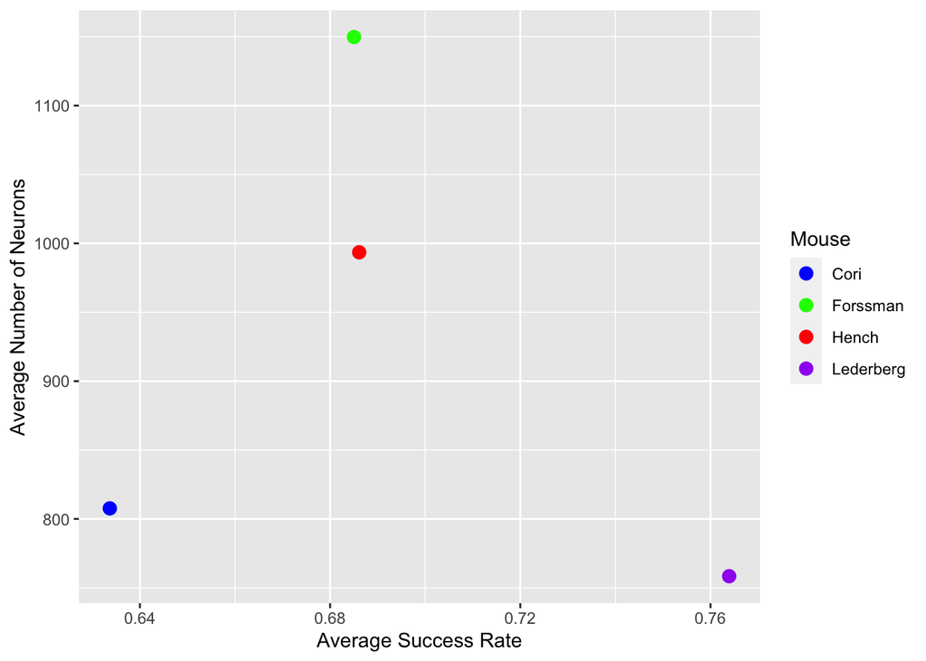

```r
library(ggplot2)

# Calculate average success rate and average number of neurons for each mouse
mouse_names <- c("Cori", "Forssman", "Hench", "Lederberg")
avg_success <- c(cori_avg_success, forssman_avg_success, hench_avg_success, lederberg_avg_success)
avg_neurons <- c(cori_avg_neurons, forssman_avg_neurons, hench_avg_neurons, lederberg_avg_neurons)

# Create a data frame with the mouse names, average success rate, and average number of neurons
data <- data.frame(Mouse = mouse_names, Avg_Success = avg_success, Avg_Neurons = avg_neurons)

# Create the dot plot
dot_plot <- ggplot(data, aes(x = Avg_Success, y = Avg_Neurons, color = Mouse)) +
  geom_point(size = 3) +
  labs(x = "Average Success Rate", y = "Average Number of Neurons") +
  scale_color_manual(values = c("Cori" = "blue", "Forssman" = "green", "Hench" = "red", "Lederberg" = "purple"))

# Display the dot plot
print(dot_plot)
```

We cannot see a clear relationship between the average n_neurons or average success rate between the 4 mice. We will investigate the variability and trends of neuron spiking activity further, as well as a better method to predict the feedback types throughout this project.

#ii.explore the neural activities during each trial

Below code summarizes the neuron spiking activity from each trial by finding the average number of spikes across neurons that live in the same area of the brain. We wrapped this code into a function taking in the session and trial number so we can easily apply this code to different sessions/trials throughout the experiment. We tried this code on session 2 trial 1, as this session and trial is also performed by Cori, the subject of the test data from session 1.

```r
i.s=2 # indicator for this session

i.t=1 # indicator for this trial

spk.trial = session[[i.s]]$spks[[i.t]]
area=session[[i.s]]$brain_area

# We need to first calculate the number of spikes for each neuron during this trial
spk.count=apply(spk.trial,1,sum)

# for(i in 1:dim(spk.trial)[1]){
#  spk.count[i]=sum(spk.trial[i,])
# }

# Next we take the average of spikes across neurons that live in the same area

# You can use tapply() or group_by() in dplyr

# tapply():
spk.average.tapply=tapply(spk.count, area, mean)


# dplyr:
# To use dplyr you need to create a data frame
tmp <- data.frame(
  area = area,
  spikes = spk.count
)
# Calculate the average by group using dplyr
spk.average.dplyr =tmp %>%
  group_by(area) %>%
  summarize(mean= mean(spikes))
```

```r
# Wrapping up the function:

average_spike_area<-function(i.t,this_session){
  spk.trial = this_session$spks[[i.t]]
  area= this_session$brain_area
  spk.count=apply(spk.trial,1,sum)
  spk.average.tapply=tapply(spk.count, area, mean)
  return(spk.average.tapply)
  }

# Test the function
average_spike_area(1,this_session = session[[i.s]])
```

```
##      CA1     POST     root     VISl    VISpm
## 1.121053 1.816754 1.538462 1.398268 2.000000
```

Now we can see the average spike counts for the areas of the brain that had active spiking neurons in session 2 trial 1 (CA1, POST, root, VIS1, VISpm)

Now we make another data frame called trial.summary that summarizes the neuron activity from all the trials in a session, also including other characteristics of the experiment that may be helpful information for the response variable of our prediction model (feedback type) such as the left stimuli value, right stimuli value, and trial id. Each experiment includes the average spike counts for all brain area where there was active neuron spiking activity.

We obtain the trial summary of session 2.

```r
n.trial=length(session[[i.s]]$feedback_type)
n.area=length(unique(session[[i.s]]$brain_area ))
# Alternatively, you can extract these information in the meta that we created before.

# We will create a data frame that contain the average spike counts for each area, feedback type,  the two contrasts, and the trial id

trial.summary =matrix(nrow=n.trial,ncol= n.area+1+2+1)
for(i.t in 1:n.trial){
  trial.summary[i.t,]=c(average_spike_area(i.t,this_session = session[[i.s]]),
                          session[[i.s]]$feedback_type[i.t],
                        session[[i.s]]$contrast_left[i.t],
                        session[[i.s]]$contrast_right[i.s],
                        i.t)
}

colnames(trial.summary)=c(names(average_spike_area(i.t,this_session = session[[i.s]])), 'feedback', 'left contr.','right contr.','id' )

# Turning it into a data frame
trial.summary <- as_tibble(trial.summary)
head(trial.summary, 15)
```

```
## # A tibble: 15 × 9
##      CA1  POST  root  VISl VISpm feedback `left contr.` `right contr.`    id
##    <dbl> <dbl> <dbl> <dbl> <dbl>    <dbl>         <dbl>          <dbl> <dbl>
##  1 1.12  1.82  1.54  1.40  2           -1          1                 0     1
##  2 0.837 1.04  0.936 0.974 1.14         1          0.25              0     2
##  3 1.02  1.29  1.21  1.18  1.47        -1          0.5               0     3
##  4 1.1   1.24  1.10  1.25  1.57         1          0.25              0     4
##  5 0.763 1.41  1.12  1.08  1.62        -1          0                 0     5
##  6 0.932 0.848 0.949 1.05  0.990        1          0                 0     6
##  7 1.13  1.72  1.01  1.19  1.81         1          1                 0     7
##  8 1.62  1.74  1.67  1.58  1.71         1          0                 0     8
##  9 0.879 1.32  0.974 1.07  1.27        -1          0                 0     9
## 10 0.826 0.759 0.872 0.939 0.887        1          0                 0    10
## 11 1.08  1.48  1.28  1.29  1.60         1          0                 0    11
## 12 1.24  1.46  1.27  1.65  1.57         1          0                 0    12
## 13 1.17  1.72  1.28  1.35  1.82        -1          0.25              0    13
## 14 1.1   1.52  1.12  1.35  1.41         1          0                 0    14
## 15 1.04  1.37  1.12  1.23  1.73        -1          1                 0    15
```

Then we create a visualization plotting the neuron spiking activities for the each area of the brain 0.4 seconds post onset. Each dot represents a neuron spike, and each area of the brain is color coded in a different color. We take a look at the neuron spiking activity in session 2 trial 1.

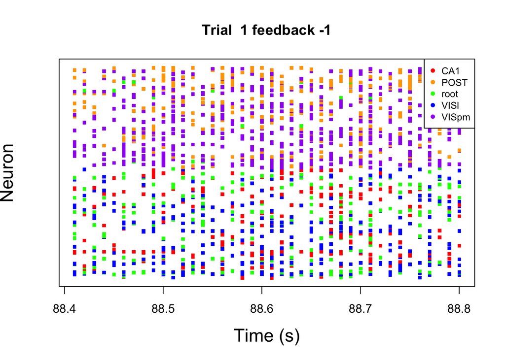

```r
area.col <- c("red","orange","green","blue", "purple")

plot.trial<-function(i.t,area, area.col,this_session){

    spks=this_session$spks[[i.t]];
    n.neuron=dim(spks)[1]
    time.points=this_session$time[[i.t]]

    plot(0,0,xlim=c(min(time.points),max(time.points)),ylim=c(0,n.neuron+1),col='white', xlab='Time (s)',yaxt='n', ylab='Neuron', main=paste('Trial ',i.t, 'feedback', this_session$feedback_type[i.t] ),cex.lab=1.5)
    for(i in 1:n.neuron){
        i.a=which(area== this_session$brain_area[i]);
        col.this=area.col[i.a]

        ids.spike=which(spks[i,]>0) # find out when there are spikes
        if( length(ids.spike)>0 ){
            points(x=time.points[ids.spike],y=rep(i, length(ids.spike) ),pch='.',cex=5, col=col.this)
        }


    }

legend("topright",
  legend = area,
  col = area.col,
  pch = 16,
  cex = 0.8
  )
  }
varname=names(trial.summary);
area=varname[1:(length(varname)-4)]
plot.trial(1,area, area.col,session[[i.s]])
```